# House Prices Version 4

Anthony Pan

2020-05-20

## Introduction

Alright, we’re going to try and predict housing prices. The goal is to predict the final sale price of residential homes in Ames, Iowa based on information about the house.

The score is judged on the root mean squared error (RMSE) of the log sale price, and this submission scores in the top 13% of results (as of May 2020).

### Import Data

The training data has 1460 observations, and the test data has 1459 observations. There are a total of 79 predictors, not including the house ID, which are described in detail [here](https://www.kaggle.com/c/house-prices-advanced-regression-techniques/data).

```r
test <- read.csv("test.csv")
train <- read.csv("train.csv")
```

## Data Pre-Processing

Let’s tidy up the dataset before diving into anything else.

```r
## separate IDs
id_train <- train$Id
procTrain <- train[, -1]

id_test <- test$Id
procTest <- test[, -1]

## use log of sale price
procTrain$SalePrice <- log(procTrain$SalePrice)

## convert factor variables to factors
procTrain$MSSubClass <- as.factor(procTrain$MSSubClass)
procTest$MSSubClass <- as.factor(procTest$MSSubClass)

procTrain$MoSold <- as.factor(procTrain$MoSold)
procTest$MoSold <- as.factor(procTest$MoSold)

# recode factor level 150 into 160 in test MSSubClass (exists in test but not train)
procTest$MSSubClass <- fct_collapse(procTest$MSSubClass, '160' = c('150', '160'))

# fix typo in GarageYrBlt
procTest$GarageYrBlt <- ifelse(procTest$GarageYrBlt == 2207, 2007, procTest$GarageYrBlt)

# fix typo in YearRemodAdd
procTest$YearRemodAdd <- ifelse(procTest$YearRemodAdd > procTest$YrSold,
                                procTest$YrSold,
                                procTest$YearRemodAdd)
procTrain$YearRemodAdd <- ifelse(procTrain$YearRemodAdd > procTrain$YrSold,
                                 procTest$YrSold,
                                 procTest$YearRemodAdd)
```

### Missing Values: Continuous

```r
### missing values
#summary(is.na(procTrain))
#summary(is.na(procTest))

# impute missing continuous values with bagged trees
full_data <- rbind(procTrain[, -80], procTest)
numeric_cols <- which(map_lgl(full_data, is.numeric))

set.seed(1001)
bagImpute <- preProcess(full_data[, numeric_cols], method = "bagImpute")
procTrain[, numeric_cols] <- predict(bagImpute, procTrain[, numeric_cols])
procTest[, numeric_cols] <- predict(bagImpute, procTest[, numeric_cols])
rm(bagImpute)
```

### Missing Values: Discrete

There are two types of missing values from discrete variables: those that represent an “other” category, and those that are truly missing.

For missing values that represent an “other” category, we create a new factor level to represent that category. For those that are truly missing, we impute missing values with the most common value from all other observations.

```r
#### convert missing factor values into an "other" type if appropriate
add_fctlevel <- c("Alley", "BsmtQual", "BsmtCond", "BsmtExposure", "BsmtFinType1", "BsmtFinType2",
                  "FireplaceQu", "GarageType", "GarageFinish", "GarageQual", "GarageCond",
                  "PoolQC", "Fence", "MiscFeature")

procTrain[, add_fctlevel] <- map_df(procTrain[, add_fctlevel], addNA)
procTest[, add_fctlevel] <- map_df(procTest[, add_fctlevel], addNA)

### impute missing factor values into most common category for all other factors
imp_fctlevel <- c("MasVnrType", "Electrical", "MSZoning", "Utilities", "Exterior1st", "Exterior2nd", "KitchenQual", "Functional", "SaleType")

# function to return mode
Mode <- function(x) {
  ux <- unique(x)
  ux[which.max(tabulate(match(x, ux)))]
}

for (fct in imp_fctlevel) {
  procTrain[[fct]][is.na(procTrain[[fct]])] <- Mode(full_data[[fct]])
  procTest[[fct]][is.na(procTest[[fct]])] <- Mode(full_data[[fct]])
}
rm(Mode, fct, add_fctlevel, imp_fctlevel)
```

### Additional Pre-Processing

1. Ordinal categorical variables are **converted to numeric** to allow for discovery of more complex relationships between levels.
2. Continuous variables are treated with a **box-cox transformation, centering, and scaling** for more stable modeling.
3. A separate train/test dataset are created by **one-hot-encoding categorical variables** so that they’re properly represented as dummy variables.

```r
### convert ordered factors to numeric
ordered_factors <- c("Alley", "LotShape", "Utilities", "LandSlope",
                     "ExterQual", "ExterCond", "BsmtQual", "BsmtCond", "BsmtExposure",
                     "BsmtFinType1", "BsmtFinType2", "HeatingQC", "KitchenQual",
                     "Functional", "FireplaceQu", "GarageFinish", "GarageQual",
                     "GarageCond", "PavedDrive", "PoolQC", "Fence")
procTrain[, ordered_factors] <- map_df(procTrain[, ordered_factors], as.numeric)
procTest[, ordered_factors] <- map_df(procTest[, ordered_factors], as.numeric)


### apply boxcox, center, and scale to continuous values
trainTrans <- preProcess(procTrain[, numeric_cols],
                         method = c("BoxCox", "center", "scale"))
procTrain[, numeric_cols] <- predict(trainTrans, procTrain[, numeric_cols])

testTrans <- preProcess(procTest[, numeric_cols],
                              method = c("BoxCox", "center", "scale"))
procTest[, numeric_cols] <- predict(testTrans, procTest[, numeric_cols])

rm(trainTrans, testTrans, ordered_factors)

### one-hot encode factors
treatplan <- designTreatmentsZ(procTrain, names(procTrain[-80]),
                               minFraction = 0.01, rareCount = 0, verbose = FALSE)
procTrainEnc <- prepare(treatplan, dframe = procTrain, codeRestriction = c("clean", "lev"))
procTestEnc <- prepare(treatplan, dframe = procTest, codeRestriction = c("clean", "lev"))
procTrainEnc$SalePrice <- procTrain$SalePrice
```

## Modeling

We will fit an elastic net model, MARS model, and polynomial SVM on the one-hot-encoded data. Stochastic gradient boosting will be performed on the data that is not one-hot-encoded, because one-hot encoding can [lead to decreased performance in decision tree-based models.](https://medium.com/data-design/visiting-categorical-features-and-encoding-in-decision-trees-53400fa65931)

Models will be evaluated with the average of 10-fold cross-validation errors, repeated 3 times. The cross-validation folds will be shared across all models for comparison later on. Model tuning and hyperparameter selection have been completed separately to decrease the amount of time it takes to run this script.

```r
set.seed(202005181)
ctrl <- trainControl(method = "repeatedcv",
                     number = 10,
                     repeats = 3,
                     index = createMultiFolds(procTrain$OverallQual, k = 10, times = 3),
                     savePredictions = "final")
```

## Elastic Net

Fitting an elastic net model leads to an average 10-fold cross-validation RMSE of .1286.

This model considers the total above ground living area (GrLivArea), followed closely by the neighborhood the house is located (neighborhood) and its overall quality (OverallQual) as the most important contributors to sale price.

```r
# glmnet RMSE: 0.1285798
glmGrid <- expand.grid(.alpha = .8,
                       .lambda = 0.005263158)
set.seed(20200518)
glmModel <- train(SalePrice ~ .,
                   procTrainEnc,
                   method = "glmnet",
                   tuneGrid = glmGrid,
                   verbose = FALSE,
                   trControl = ctrl)

glmModel
```

```
## glmnet
##
## 1460 samples
##  182 predictor
##
## No pre-processing
## Resampling: Cross-Validated (10 fold, repeated 3 times)
## Summary of sample sizes: 1313, 1314, 1315, 1315, 1314, 1314, ...
## Resampling results:
##
##   RMSE       Rsquared   MAE
##   0.1285798  0.8944249  0.0834132
##
## Tuning parameter 'alpha' was held constant at a value of 0.8
## Tuning
##  parameter 'lambda' was held constant at a value of 0.005263158
```

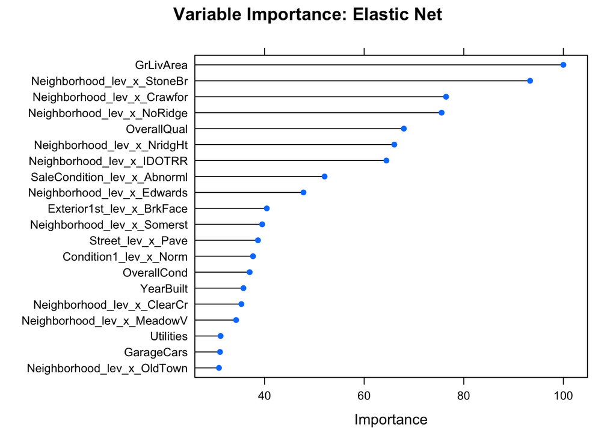

```r
plot(varImp(glmModel), top = 20, main = "Variable Importance: Elastic Net")
```

### MARS

A MARS (multivariate adaptive regression splines) model performs marginally worse, with an RMSE of .1297.

However, only 11 predictors are used to determine the sale price, the most important being overall quality of the house (OverallQual). The model is sparse, and likely won’t overfit the data compared to the other, more flexible models.

```r
# MARS model RMSE: .1297
earthGrid <- expand.grid(.degree = 1,
                         .nprune = 35)
set.seed(20200518)
earthModel <- train(SalePrice ~ .,
                    procTrainEnc,
                    method = "earth",
                    tuneGrid = earthGrid,
                    trControl = ctrl)
earthModel
```

```
## Multivariate Adaptive Regression Spline
##
## 1460 samples
##  182 predictor
##
## No pre-processing
## Resampling: Cross-Validated (10 fold, repeated 3 times)
## Summary of sample sizes: 1313, 1314, 1315, 1315, 1314, 1314, ...
## Resampling results:
##
##   RMSE       Rsquared   MAE
##   0.1296925  0.8948072  0.08815324
##
## Tuning parameter 'nprune' was held constant at a value of 35
## Tuning
##  parameter 'degree' was held constant at a value of 1
```

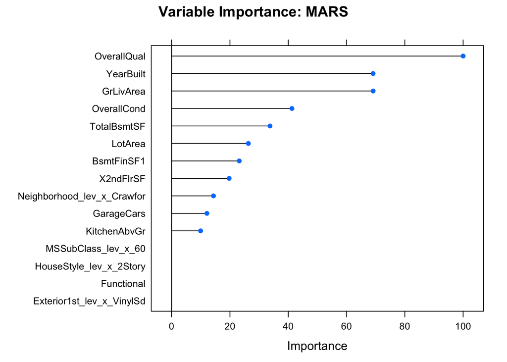

```r
plot(varImp(earthModel), top = 15, main = "Variable Importance: MARS")
```

### Polynomial Support Vector Machine

The best-performing polynomial SVM has a degree of 1, and returns an average cross-validated RMSE of .1262, which is slightly better than the two previous models.

Like the MARS model, the SVM is most reliant on overall house quality in determining sale price. However, the SVM considers more variables as important, and differs in its selection of moderately important variables.

```r
# svm poly RMSE: .1262140
svmPolyGrid <- expand.grid(.degree = 1,
                           .C = .25,
                           .scale = .01)
set.seed(20200518)
svmPModel <- train(SalePrice ~ .,
                  data = procTrainEnc,
                  method = "svmPoly",
                  tuneGrid = svmPolyGrid,
                  trControl = ctrl)

svmPModel
```

```
## Support Vector Machines with Polynomial Kernel
##
## 1460 samples
##  182 predictor
##
## No pre-processing
## Resampling: Cross-Validated (10 fold, repeated 3 times)
## Summary of sample sizes: 1313, 1314, 1315, 1315, 1314, 1314, ...
## Resampling results:
##
##   RMSE      Rsquared   MAE
##   0.126214  0.8968345  0.07804959
##
## Tuning parameter 'degree' was held constant at a value of 1
## Tuning
##  parameter 'scale' was held constant at a value of 0.01
## Tuning parameter
##  'C' was held constant at a value of 0.25
```

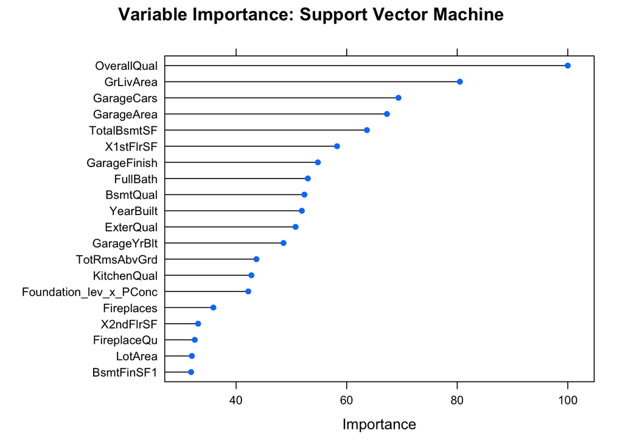

```r
plot(varImp(svmPModel), top = 20, main = "Variable Importance: Support Vector Machine")
```

### Stochastic Gradient Boosting

Applying stochastic gradient boosting yields an average cross-validated error of .1235, which is the best among all of the models we’ve evaluated.

Like MARS and SVM, overall house quality is treated as most important in determining sale price; however, boosting is unique in that overall quality is 2.5 times more important than the next most significant variable.

```r
# gbm model: RMSE .12346
gbmGrid <- expand.grid(.interaction.depth = 7,
                        .n.trees = 2000,
                        .shrinkage = .02,
                        .n.minobsinnode = 15)
set.seed(20200518) #
gbmModel <- train(SalePrice ~ .,
                  data = procTrain,
                  method = "gbm",
                  tuneGrid = gbmGrid,
                  verbose = FALSE,
                  trControl = ctrl)

gbmModel
```

```
## Stochastic Gradient Boosting
##
## 1460 samples
##   79 predictor
##
## No pre-processing
## Resampling: Cross-Validated (10 fold, repeated 3 times)
## Summary of sample sizes: 1313, 1314, 1315, 1315, 1314, 1314, ...
## Resampling results:
##
##   RMSE       Rsquared   MAE
##   0.1234612  0.9049215  0.08324457
##
## Tuning parameter 'n.trees' was held constant at a value of 2000
##
## Tuning parameter 'shrinkage' was held constant at a value of 0.02
##
## Tuning parameter 'n.minobsinnode' was held constant at a value of 15
```

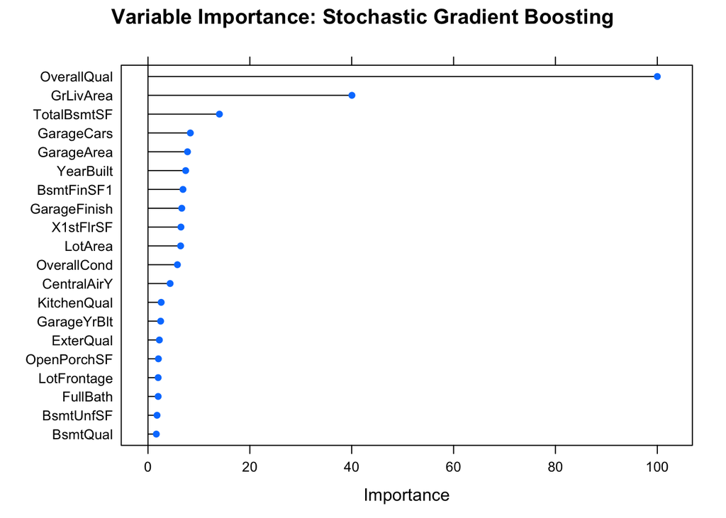

```r
plot(varImp(gbmModel), top = 20, main = "Variable Importance: Stochastic Gradient Boosting")
```

### Ensemble

Since we used the same 10-fold cross-validation samples for all of our models, we can compare the models among each fold to determine the best linear combination of model predictions for the training dataset. This allows us to draw on the strengths of all four models.

The first table below shows a comparison of the RMSE values between all models.

The second table below shows correlation between models. The two most correlated models are elastic net and SVM, likely because they both have linear decision boundaries. Other than this relationship, all other model pairs have a correlation between 0.7 and 0.8.

```r
tuneList <- list(glmnet = caretModelSpec(method = "glmnet", tuneGrid = glmGrid))
set.seed(20200518)
modelList <<- caretList(SalePrice ~ .,
                        data = procTrainEnc,
                        trControl = ctrl,
                        metric = "RMSE",
                        tuneList = tuneList)
modelList[["svmP"]] <- svmPModel
modelList[["gbm"]] <- gbmModel
modelList[["earth"]] <- earthModel

summary(resamples(modelList))[[3]]$RMSE
```

```
##              Min.   1st Qu.    Median      Mean   3rd Qu.      Max. NA's
## glmnet 0.09480520 0.1075853 0.1191850 0.1285798 0.1381259 0.2131585    0
## svmP   0.08270952 0.1025115 0.1110635 0.1262140 0.1379878 0.2271063    0
## gbm    0.09487778 0.1100259 0.1222756 0.1234612 0.1349662 0.1630017    0
## earth  0.09915494 0.1146958 0.1288019 0.1296925 0.1403361 0.1884641    0
```

```r
modelCor(resamples(modelList))
```

```
##           glmnet      svmP       gbm     earth
## glmnet 1.0000000 0.9217857 0.7935552 0.7763454
## svmP   0.9217857 1.0000000 0.7513010 0.7120612
## gbm    0.7935552 0.7513010 1.0000000 0.7742894
## earth  0.7763454 0.7120612 0.7742894 1.0000000
```

The ensemble is created from the best linear combination of the four models, using their shared cross-validation resampling indexes.

```r
# weighted ensemble
set.seed(20200518)
greedyEnsemble <- caretEnsemble(modelList,
                                metric = "RMSE",
                                trControl = trainControl(method = "repeatedcv", number=10, repeats = 5))
summary(greedyEnsemble)
```

```
## The following models were ensembled: glmnet, svmP, gbm, earth
## They were weighted:
## -0.1401 -0.068 0.302 0.4625 0.315
## The resulting RMSE is: 0.1193
## The fit for each individual model on the RMSE is:
##  method      RMSE     RMSESD
##  glmnet 0.1285798 0.03150953
##    svmP 0.1262140 0.03755677
##     gbm 0.1234612 0.01693680
##   earth 0.1296925 0.02144243
```

## Results

The model ensemble made up of elastic net, MARS, SVM, and stochastic gradient boosting scored a RMSE of .11831 (top 13%).

To improve results, exploring the dataset to gain a better understanding and playing around with new features may lead to increased predictive power. Checking for outliers may also improve the robustness of the models.

```r
# prepare data for prediction
procTestEnc$Id <- id_test
procTest$Id <- id_test
procTestX <- full_join(procTest, procTestEnc, by = procTest$id_test)

# predict and save results
procTestX$LogSalePrice <- predict(greedyEnsemble, procTestX)
procTestX$SalePrice <- exp(procTestX$LogSalePrice)

submission <- tibble("Id" = procTestX$Id,
                     "SalePrice" = procTestX$SalePrice)

write.csv(submission, "submission.csv", row.names = FALSE, quote = FALSE)
```